# STAT 184 Activity 7

Solutions

Thursday, October 20

## Front Matter

```r
remove(list = ls())
library(tidyverse)
```

## Preliminaries

```r
#Read in Data
data("iris")
head(iris)
```

|  | Sepal.Length | Sepal.Width | Petal.Length | Petal.Width | Species |
| --- | --- | --- | --- | --- | --- |
| 1 | 5.1 | 3.5 | 1.4 | 0.2 | setosa |
| 2 | 4.9 | 3.0 | 1.4 | 0.2 | setosa |
| 3 | 4.7 | 3.2 | 1.3 | 0.2 | setosa |
| 4 | 4.6 | 3.1 | 1.5 | 0.2 | setosa |
| 5 | 5.0 | 3.6 | 1.4 | 0.2 | setosa |
| 6 | 5.4 | 3.9 | 1.7 | 0.4 | setosa |

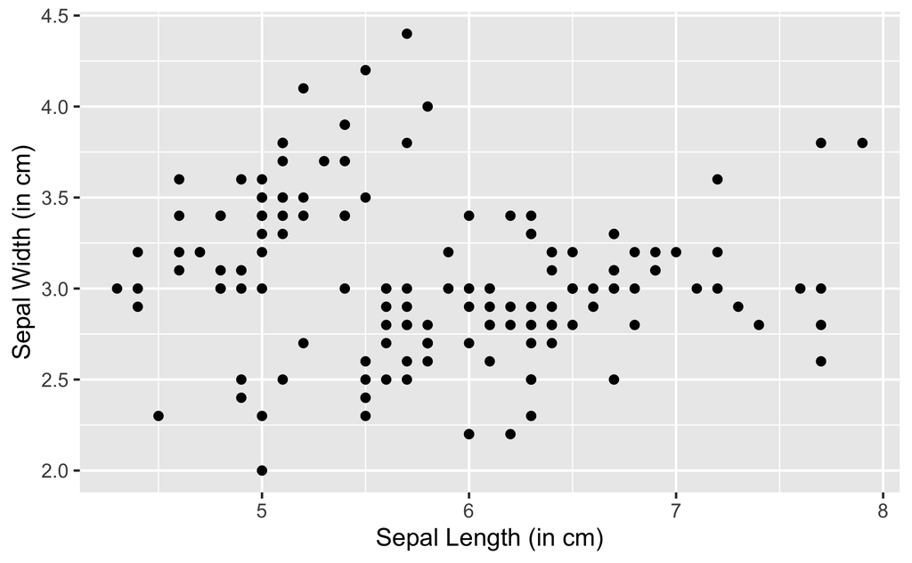

```r
#Basic Plot 1
ggplot(data = iris, mapping = aes(x = Sepal.Length,
                                  y = Sepal.Width)) +
  geom_point() +
  labs(x = "Sepal Length (in cm)",
       y = "Sepal Width (in cm)")
```

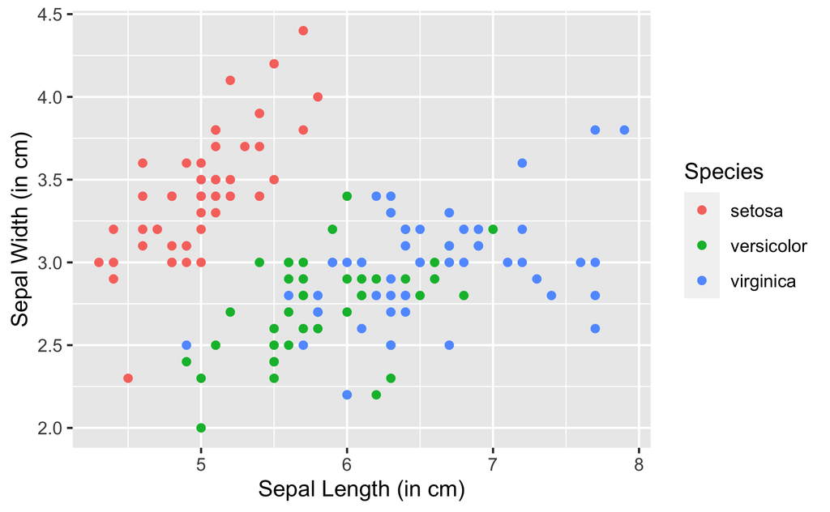

```r
#Basic Plot 2
ggplot(data = iris, mapping = aes(x = Sepal.Length,
                                  y = Sepal.Width,
                                  color = Species)) +
  geom_point() +
  labs(x = "Sepal Length (in cm)",
       y = "Sepal Width (in cm)")
```

## Problem 1

In this problem, we are controlling the color by choosing a specific color. Since we are not mapping the color to a variable, you will do this outside of aes function. Specifically, add `color = "orange"` within the `geom_point()` function.

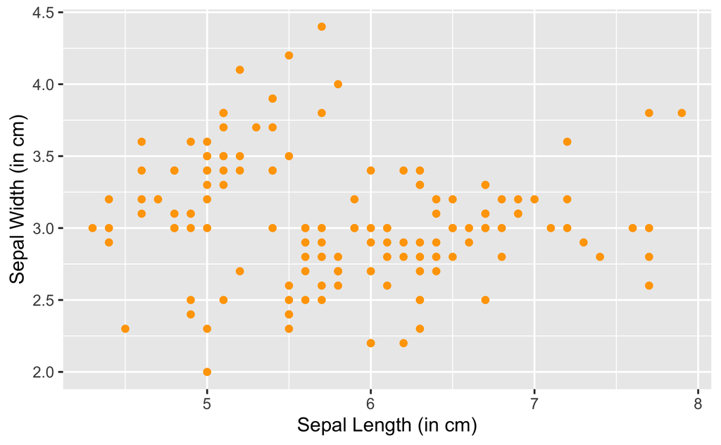

```r
ggplot(data = iris, mapping = aes(x = Sepal.Length, y = Sepal.Width)) +
  geom_point(color = "orange") +
  labs(x = "Sepal Length (in cm)",
       y = "Sepal Width (in cm)")
```

## Problem 2

The key to this is to use the `scale_color_manual()` function.

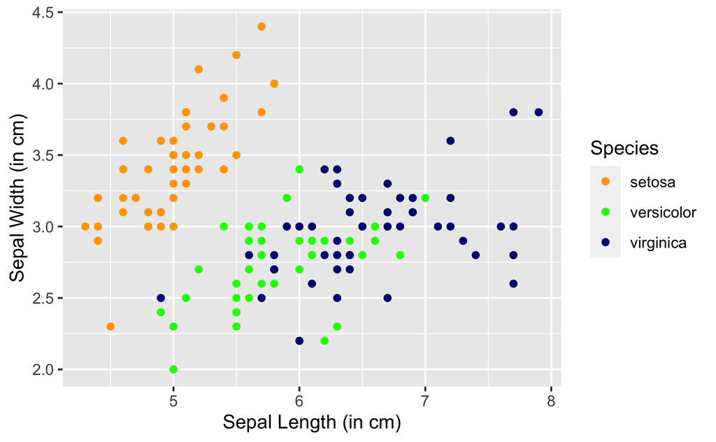

```r
ggplot(data = iris, mapping = aes(x = Sepal.Length,
                                  y = Sepal.Width,
                                  color = Species)) +
  geom_point() +
  labs(x = "Sepal Length (in cm)",
       y = "Sepal Width (in cm)") +
  scale_color_manual(values = c("orange", "green", "navy"))
```

## Problem 3

The key to this is to use `legend.position = "bottom"` in the `theme` function. The `theme` function provides a lot of customization options for various aspects of ggplot. Here, we are only modifying the legend position.

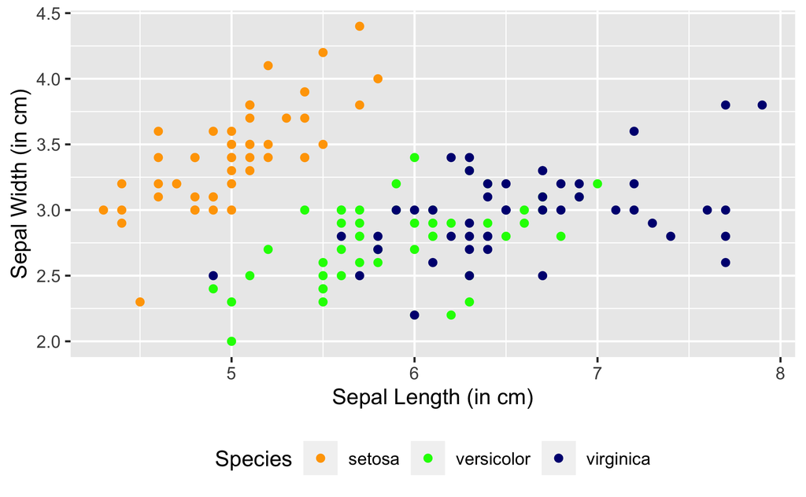

```r
ggplot(data = iris, mapping = aes(x = Sepal.Length,
                                  y = Sepal.Width,
                                  color = Species)) +
  geom_point() +
  labs(x = "Sepal Length (in cm)",
       y = "Sepal Width (in cm)") +
  scale_color_manual(values=c("orange", "green", "navy")) +
  theme(legend.position="bottom")
```

## Problem 4

The tutorial in Lecture 5 showed us how to add titles and substitles. In the `labs` function, we can specify `title = "Text"` and `subtitle = "Text"`.

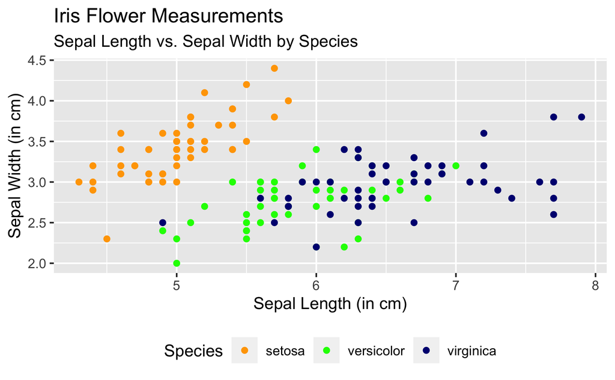

```r
ggplot(data = iris, mapping = aes(x = Sepal.Length,
                                  y = Sepal.Width,
                                  color = Species)) +
  geom_point() +
  labs(x = "Sepal Length (in cm)",
       y = "Sepal Width (in cm)",
       title = "Iris Flower Measurements",
       subtitle = "Sepal Length vs. Sepal Width by Species") +
  scale_color_manual(values=c("orange", "green", "navy")) +
  theme(legend.position="bottom")
```

## Problem 5

The language “sepal width as a function of sepal length” means that sepal width should go on the y-axis and sepal length goes on the x axis. There are many ways to do the faceting. My technique uses `facet_grid( . ~ species)`. We can add the line of best fit by using `geom_smooth(method = lm, se = FALSE)`. The `method = lm` specifies that we use a linear model (lm) to perform the smoothing. The `se = FALSE` removes the gray standard error boundaries. The `theme_bw()` removes the gray background.

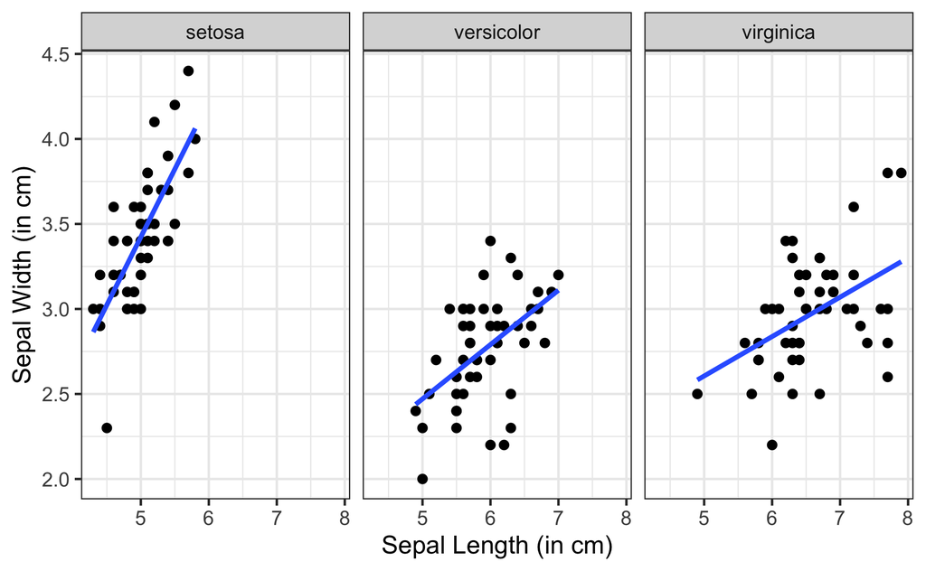

```r
ggplot(data = iris, mapping = aes(x = Sepal.Length,
                                  y = Sepal.Width)) +
  geom_point() +
  geom_smooth(method = lm, se = FALSE) +
  facet_grid( . ~ Species) +
  labs(x = "Sepal Length (in cm)",
       y = "Sepal Width (in cm)") +
  theme_bw()
```

## Problem 6

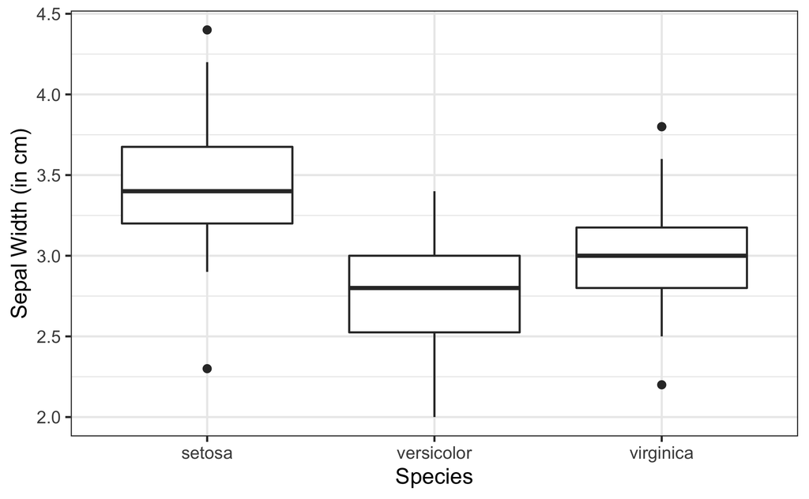

```r
ggplot(data = iris, mapping = aes(x = Species,
                                  y = Sepal.Width)) +
  geom_boxplot() +
  labs(x = "Species",
       y = "Sepal Width (in cm)") +
  theme_bw()
```

## Problem 7

My technique for this is to use the `factor` function and within `factor`, I used the `levels` argument to change the order of the levels. Instead of R determining the order of the factor levels, this allows me to specify the order as I want it to be.

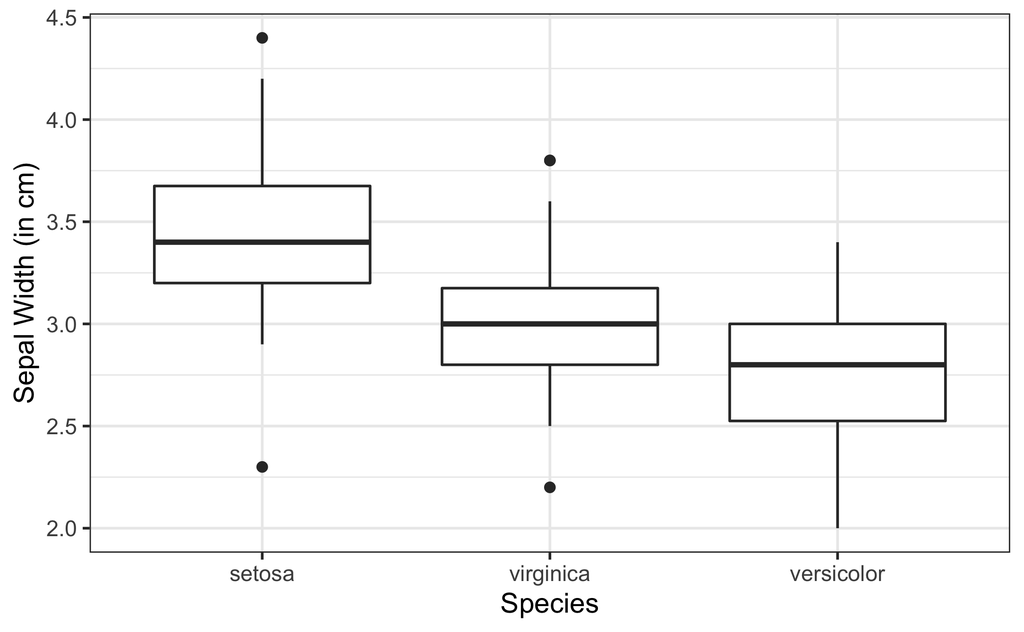

```r
iris2 <-
  iris %>%
  mutate(Species = factor(Species,
                          levels = c("setosa", "virginica", "versicolor")))

ggplot(data = iris2, mapping = aes(x = Species, y = Sepal.Width)) +
  geom_boxplot() +
  labs(x = "Species",
       y = "Sepal Width (in cm)") +
  theme_bw()
```

## Problem 8

This problem is a little tricky. In order to do this, we will use the `scale_x_continuous()` function. Within it we need to specify TWO arguments. Use `breaks = seq(4, 8, 0.5)`. This adds extra tick marks; however, the x axis is only going to 4.5 instead of 4. To modify this, you should also specify `limits = c(4, 8)` insdie the `scale_x_continuous()` function.

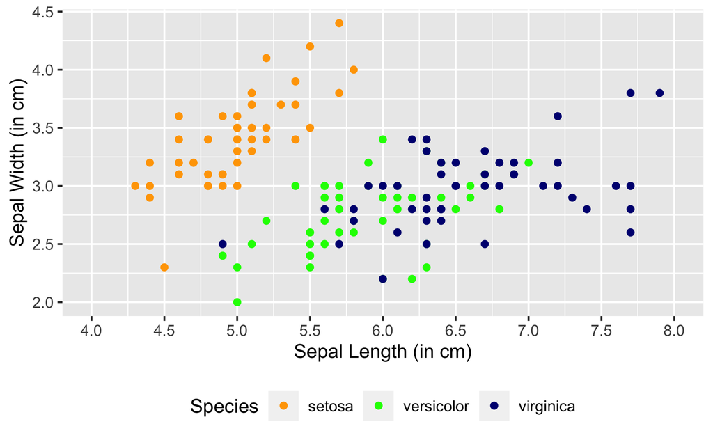

```r
ggplot(data = iris, mapping = aes(x = Sepal.Length, y = Sepal.Width,
                                  color = Species)) +
  geom_point() +
  labs(x = "Sepal Length (in cm)",
       y = "Sepal Width (in cm)") +
  scale_color_manual(values=c("orange", "green", "navy")) +
  theme(legend.position="bottom") +
  scale_x_continuous(breaks = seq(4,8,0.5), limits = c(4,8
                                                       ))
```